# Factors that affect Final Math Grades in Public schools

Daniel Odoom, Huan Yi Lee,Weiyin Deng, Lydia Finkbeinei and Hameed Shogeyinbo

Last updated on 2022-12-04

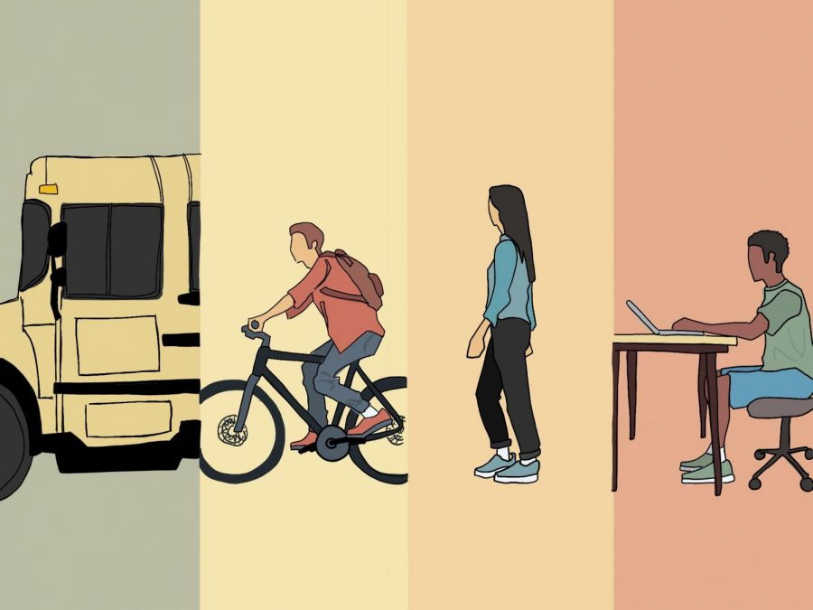

# 1. Introduction

As students, we know how commuting to school can be very tiresome and challenging [^1] . Travelling to school becomes even more difficult when you live further away from school than others. Our study aims to comprehend how students’ conditions, e.g., how far their house is from school, influences their grades. Our project analyzes whether factors such as absences and travel time to school are connected to their performance in final exams. Finding the data was essential as it would give us more insights and help us address the question. We acquired our dataset from Kaggle[^2]. It surveyed students’ math and Portuguese language courses in two secondary schools. The data contained the final math and Portuguese grades, but we used their final math grade as the outcome variable. The numerical variable was absences, and our categorical variable in our project was the travel time, with four levels, “1”( < 15 mins), “2”(15~30 mins), “3”(30 mins ~ 1 hour) and “4”(> 1 hour). Shown below is a preview of 5 randomly chosen rows of the data set we will use:

| final_math_grade | absences | traveltime |
| --- | --- | --- |
| 15 | 0 | 15~30 mins |
| 10 | 10 | < 15 mins |
| 16 | 5 | < 15 mins |
| 0 | 0 | 15~30 mins |
| 10 | 19 | < 15 mins |

# 2. Exploratory data analysis

In our dataset, we had a sample size of 395 students(Table 1), and we were fortunate not to find any missing values. The mean of the travel time was greatest for students who spent less than 15 minutes going to school (n = 257, $\bar{x}$ = 10.8, sd = 4.52), intermediate for those who spent around 15-30 minutes going to school (n = 107, $\bar{x}$ = 9.91, sd = 4.60) and students who spent 30 minutes to an hour travelling to school(n = 23, $\bar{x}$ = 9.26, sd = 5.07). Lastly, it was lowest for students who spent more than 1 hour commuting to school (n = 8, $\bar{x}$ = 8.75, sd = 3.92). The average number of absences for students was 5.71(sd =8.00).

Table 1. Summary statistics of final Math grades for students travel less than 15 mins, 15 to 30 mins, 30 mins to 1 hour, more than 1 hour to school.

| traveltime | n | mean | median | sd | min | max |
| --- | --- | --- | --- | --- | --- | --- |
| < 15 mins | 257 | 10.782101 | 11 | 4.523289 | 0 | 20 |
| 15~30 mins | 107 | 9.906542 | 10 | 4.600108 | 0 | 19 |
| 30 mins ~ 1 hour | 23 | 9.260870 | 10 | 5.074154 | 0 | 18 |
| > 1 hour | 8 | 8.750000 | 10 | 3.918819 | 0 | 13 |

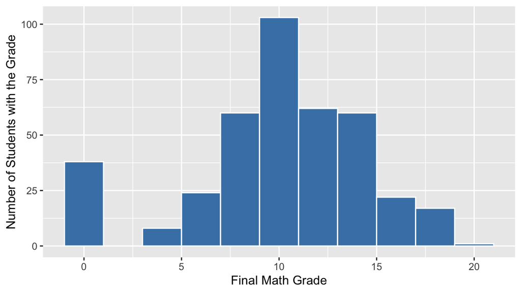

Figure 1. Historgram of Math Grades

In Figure 2, we developed a scatterplot to see the overall relationship between the number of school absences and the final math grade, and we observed a relationship between them. Although, it is a very weak positive correlation with a (slightly) positive line of best fit. Initially, we assumed there would be no relationship as the points on the scatter plot seem to be scattered randomly on the left side of the plot. Likewise, there’s weak to little association between these two variables.

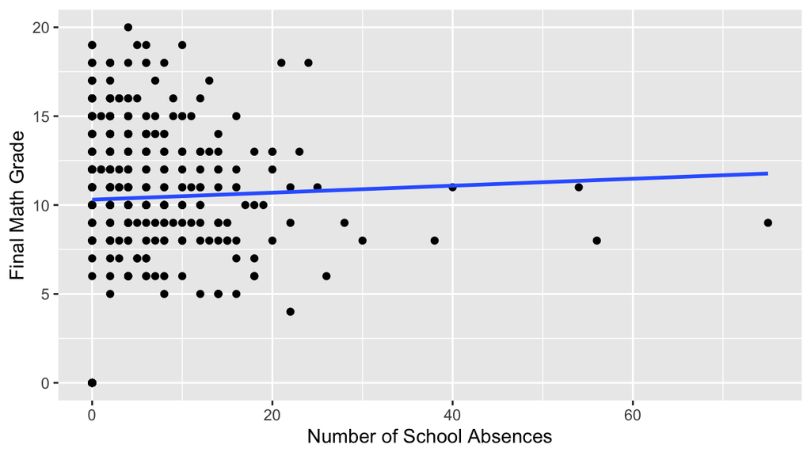

Figure 2. School Absences compared to Math Grades

As shown in figure 3, the Final math grade was the highest in the group of students with the lowest travel time and the lowest within the group with the highest travel time. Most box plots had an outlier(Grade 0), but the box plot students with the highest travel time had more outliers.

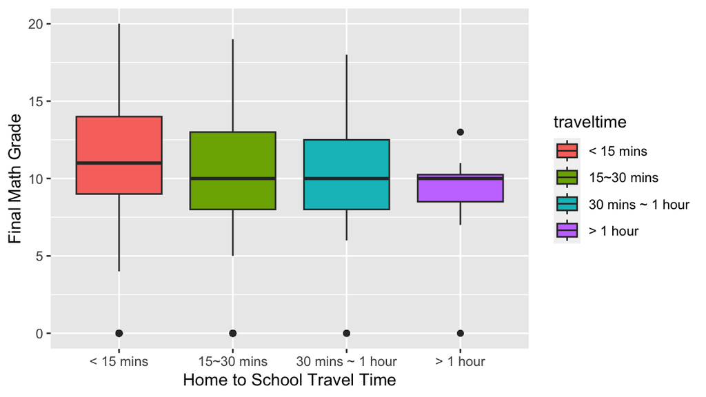

Figure 3. Boxplot of Travel Time compared to Math Grade

As for the coloured scatter plot, we could see the differences in correlations between the categories, allowing the viewer to visualize the differences in sample sizes better. Likewise, the non parallel relationship between the lines imply an interaction effect between the variables.Despite low correlation values, all lines appear positive, implying a positive relationship. There seems to be some interaction between the categories, and all four categories vary slightly in their slopes.

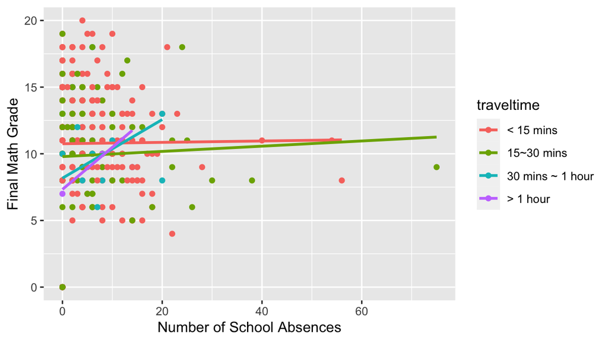

Figure 4. Colored Scatterplot of Math Grades compared to Absences

# 3. Multiple linear regression

## 3.1 Methods

The components of our multiple linear regression model are the following:

- Outcome variable $y$ = Final Math grade
- Numerical explanatory variable $x_1$ = Times of absences
- Categorical explanatory variable $x_2$ = Travel time from home to school

## 3.2 Model Results

Table 2. Regression table of parallel slopes model of Final Math Grade as a number of school absences and travel time.

| term | estimate | std_error | statistic | p_value | lower_ci | upper_ci |
| --- | --- | --- | --- | --- | --- | --- |
| intercept | 10.674 | 0.329 | 32.483 | 0.000 | 10.028 | 11.320 |
| absences | 0.019 | 0.029 | 0.661 | 0.509 | -0.038 | 0.076 |
| traveltime: 15~30 mins | -0.882 | 0.526 | -1.678 | 0.094 | -1.916 | 0.152 |
| traveltime: 30 mins ~ 1 hour | -1.508 | 0.995 | -1.515 | 0.131 | -3.464 | 0.448 |
| traveltime: > 1 hour | -2.010 | 1.641 | -1.225 | 0.221 | -5.236 | 1.217 |

## 3.3 Interpreting the regression table

The regression equation for Final Math Grade is the following:

$$
$$\begin{aligned}\widehat {grade} =&
b_{0} + b_{abs} \cdot abs + b_{15 to 30 mins} \cdot 1_{is\ 15 to 30
mins}(x_2) + b_{30 to 1 hour} \cdot 1_{is\ 30 to 1 hour}(x_2) + b_{>
1 hour} \cdot 1_{is\ > 1 hour}(x_2)\\
=& 10.674 + 0.019 \cdot abs - 0.882 \cdot 1_{is\ 15 to 30 mins
}(x_2) - 1.508 \cdot 1_{is\ 30 mins to 1 hour}(x_2) - 2.010 \cdot 1_{is\
> 1 hour}(x_2)
\end{aligned}$$

$$

The intercept ($b_0$ = 10.674) represents the final math grade when the students are said to be not absent and the travel time is less than 15 minutes (Table 2). * The estimate for the slope for absences($b_{abs}$ = 0.019) is the associated change in the final math grade depending on the number of students. Based on this estimate, there was an associated increase in the final math grade of, on average, 0.019 points for every increase in a student’s absences. * The estimate for travel time: 15~30 mins ($b_{15to30mins}$ = -0.882) , 30 mins ~ 1 hour ($b_{30to1hour}$ = -1.508) and > 1 hour($b_{>1hour}$ = -2.010)are the offsets in intercept relative to the baseline group’s, less than 15 minutes, intercept (Table 2). In other words, students who take around 15-30 minutes of travel time scored -0.882 lower than those who spend less than 15 minutes. Likewise, students who spent 30 minutes to an hour of travel time scored on average -1.508 and those who spent more than an hour commuting scored on average -2.010 lower.

Thus the four regression lines have equations:

$$
$$\begin{aligned}
\text{< 15 mins (in red)}: \widehat {grade} =& 10.674 + 0.019
\cdot prct\\
\text{15 ~ 30 mins (in green)}: \widehat {grade} =& 9.792 + 0.019
\cdot prct\\
\text{30mins ~ 1 hour (in blue)}: \widehat {grade} =& 9.166 + 0.019
\cdot prct\\
\text{> 1 hour (in purple)}: \ widehat [grade] =& 8.664 + 0.019
\cdot prct
\end{aligned}$$

$$

## 3.4 Inference for multiple regression

Using the output of our regression table, we’ll test two different null hypotheses, using an alpha of 0.05 to assess the p-value. First, we’re asking: Does the data display a relationship between grades and absences? Second, we’re asking: Does the data show significant differences between the travel times? The first null hypothesis is that there is no relationship between the final math grade and the number of absences.
$$\begin{aligned}
\text{ }{H}_{0}: β_{absence}= 0\\
\text{vs }{H}_{A}: β_{absence}≠ 0
\end{aligned}$$

The second null hypothesis we can test is that there is no statistical difference between the relationships of final grades and travel times.
$$\begin{aligned}
\text{ }{H}_{0}: β_{15~to~30mins}= 0\\
\text{vs }{H}_{A}: β_{15~to~30mins}≠ 0
\end{aligned}$$
and
$$\begin{aligned}
\text{ }{H}_{0}: β_{30mins~to~1hr}= 0\\
\text{vs }{H}_{A}: β_{30mins~to~1hr}≠ 0
\end{aligned}$$

and
$$\begin{aligned}
\text{ }{H}_{0}: β_{>~1hr}= 0\\
\text{vs }{H}_{A}: β_{>~1hr}≠ 0
\end{aligned}$$

Using categorical travel time data, we can see that the table shows the relations between intercepts

- 15-30 minutes has a residual stat of -1.678 and a p-value of 0.094
- 30-60 minutes has a residual stat of -1.515 and a p-value of 0.131
- more than 60 minutes has a residual stat of -1.225 and a p-value of 0.221

## 3.5 Residual Analysis

Histogram of residuals

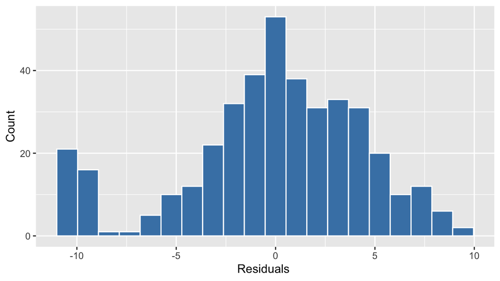

Figure 5. Histogram of residuals for statistical model

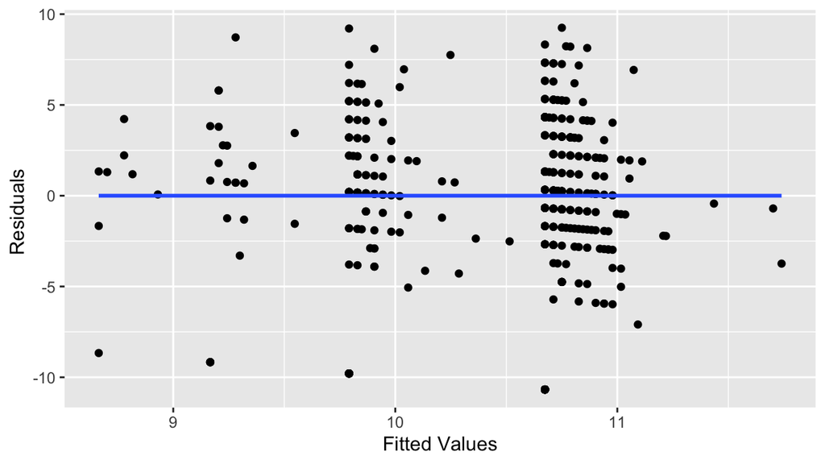

Figure 6. Scatterplots of residulas against the fitted values

[figure not shown]

Figure 7. Scatterplots of residuals against the numerical explanatory variable

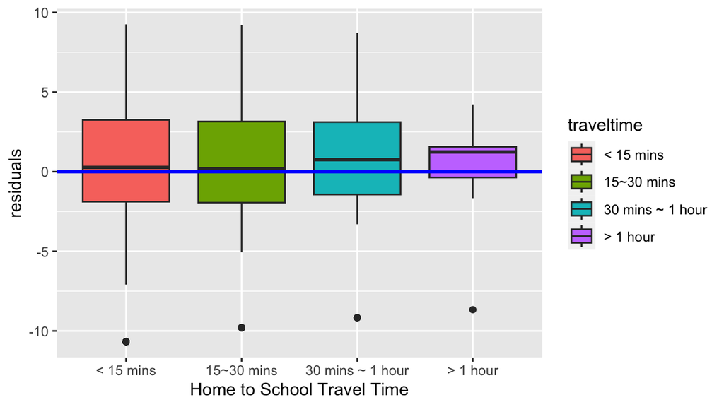

# 4. Discussion

## 4.1 Conclusions

We found that there is no significant difference in average final math grades between students with different travel times, as well as no significant difference between students with more absences. Despite that, as travel times increased, there was a slight average decrease in final grades; these intervals do not appear to be statistically significant. We were surprised by these results, as we expected higher travel times and higher absences to impact the final grades rather than showing no difference and no relationship. Our initial thought process was that students with many absences have less in-class time, which impacts their grades, and students with higher travel times are more likely to be absent. However, this does not appear to be the case.

Overall, these results imply that, generally, travel time to school does not have a statistical impact on the student’s math grades, and neither do absences from school. Our findings are consistent with other studies[^3]. Understanding that absences from school have minimal effect on performance, schools should better encourage the well-being of students by removing any programs reliant on ‘perfect attendance. These findings should also be communicated to parents, especially those who push their children to attend school when sick to maintain their ’perfect attendance,’ encouraging students to stay home when sick. In a society that just experienced a pandemic, these facts are especially important. ## 4.2 Limitations There are several limitations to our data set. The most notable one would be that our data set focuses on two schools in Portugal located in two different cities(Evora and Portalegre). Thus, our scope of inference is limited to those two cities in Portugal, and it will not be appropriate to generalize our results to the whole of Portugal. Likewise, the grades given were for two subjects, maths and Portuguese. Hence, if they have low grades in their math finals, they could have scored better on others. If the data had their overall GPA, we could make better conclusions.

## 4.3 Further questions

Numerous questions popped up while researching our topic. First and foremost, a data set that informs you of the student’s GPA for the entire year to make better conclusions. Likewise, a data set includes several years of data to see if the trends persist from year to year. Thus, it would be interesting to have other explanatory variables, particularly ones that can help the government and schools address and provide additional resources to those struggling with academics. In addition, expanding our data would be another step further in our research. Instead of focusing on two different cities- we would gather data from other towns across Portugal, enabling us to get a broader view of Portugal’s public education system. Likewise, we could compare Portugal’s’s public education system to other European systems ano students who face a similar issue. As commuting is very common and a huge issue amongst students. Lastly, we would like to question how Covid has played a role in how students commute to school and their grades.[^4]

# 5. Citations and References

[^1]: “Research Shows Relationship between Student Commuting and Academic Success.” Research Shows Relationship between Student Commuting and Academic Success | OCAD University, https://www.ocadu.ca/news/research-shows-relationship-between-student-commuting-and-academic-success.
[^2]: Learning, UCI Machine. “Student Alcohol Consumption.” Kaggle, 19 Oct. 2016, https://www.kaggle.com/datasets/uciml/student-alcohol-consumption?resource=download.
[^3]: Baliyan, Som Pal. How Distance to School and Study Hours after School Influence Students … https://www.researchgate.net/publication/343079694_How_Distance_to_School_and_Study_Hours_after_School_Influence_Students'_Performance_in_Mathematics_and_English_A_Comparative_Analysis.
[^4]: Campisi, Tiziana, et al. “Will the Effects of COVID-19 on Commuting and Daily Activities of the University Students Be Maintained? Evidence from a Small Town in Sicily.” MDPI, Multidisciplinary Digital Publishing Institute, 10 May 2022, https://www.mdpi.com/2071-1050/14/10/5780/htm.